# Terns mass trends over time

By age class and breeding status - issue #5 task 3

2026-09-08

# 1 Background

Issue #5 task 3 asks whether there’s a temporal trend in body condition (mass vs. year), per species. Extended per Inbal’s request to compare that trend across **three groups**, per species:

1. **Juveniles** - this-year fledglings (EURING age 3), representing post-fledging condition.
2. **Adult breeders** - spring-caught adults confirmed to have stayed to breed (the task 2c / any-year site-fidelity definition from `02_mass_analysis.Rmd`).
3. **Adult non-breeders** - spring-caught adults with no summer sighting in any year (presumed passage migrants, not confirmed as Atlit breeders).

This checks whether a mass trend (if any) is driven by a specific age/breeding-status class, rather than the population as a whole.

# 2 Data loading

```r
raw_dir <- "../data_raw"
if (!dir.exists(raw_dir)) raw_dir <- "data_raw"
stopifnot(dir.exists(raw_dir))

proc_dir <- "../data_processed"
if (!dir.exists(proc_dir)) proc_dir <- "data_processed"

out_dir <- "../output"
if (!dir.exists(out_dir)) out_dir <- "output"

ringing_path <- file.path(raw_dir, "ringing_data_raw.xlsx")
stopifnot(file.exists(ringing_path))

col_names_47 <- c(
  "CR1","RingReplace","Rec","RingPrefix","RingNum","Species","Sex","Age","Wing","Weight",
  "Date","Time","Place","Lat","Lon","Ringer","Country","Remarks","Net","CR2","Subsp","Tail","Head",
  "Breeding","CP1","CP2","CP3","CP4","Colour","D","M","OrigDate","OrigCountry","OrigLat","OrigLon","OrigAge",
  "OldCR1","OldCR2","OldCR3","OldMetal1","OldMetal2","OilHead","OilWings","OilUpperP","OilUnderP","OilLegs","OilSum"
)
raw <- read_excel(ringing_path, sheet = "Data", skip = 2, col_names = col_names_47)

terns <- raw %>%
  filter(Species %in% c("STEALB", "STEHIR")) %>%
  mutate(
    year = year(Date),
    month = month(Date),
    ring_id = paste0(trimws(RingPrefix), RingNum),
    is_new = is.na(Rec) | trimws(Rec) == "",
    species_label = ifelse(Species == "STEHIR", "Common Tern", "Little Tern")
  )
```

# 3 Building the three comparison groups

## 3.1 Juveniles (age 3, Jun-Aug)

Unlike the adult analyses (spring, Mar-May), juveniles can only be measured once they’re in the nest/newly fledged, i.e. during the breeding season. Window is Jun-**Aug** here (wider than the Jun-Jul used for adult breeding-season mass in task 2) because juvenile catches remain substantial into August (e.g. Common Tern age-3 catches: Jun=106, Jul=1442, Aug=1049 - dropping the August tail would discard a large, non-trivial share of the juvenile data for no analogous reason to why adults were restricted to Jun-Jul).

```r
juvenile_records <- terns %>%
  filter(is_new, Age == 3, !is.na(Weight), month %in% 6:8)

juvenile_mass <- juvenile_records %>%
  group_by(year, Species, species_label) %>%
  summarise(mean_weight = mean(Weight), sd_weight = sd(Weight), n = n(), .groups = "drop") %>%
  mutate(group = "Juvenile")

kable(juvenile_mass %>% select(-species_label), digits = 2, caption = "Juvenile (age 3) mean weight, Jun-Aug")
```

Juvenile (age 3) mean weight, Jun-Aug

| year | Species | mean_weight | sd_weight | n | group |
| --- | --- | --- | --- | --- | --- |
| 2010 | STEALB | 44.15 | 3.08 | 20 | Juvenile |
| 2010 | STEHIR | 115.77 | 11.00 | 31 | Juvenile |
| 2011 | STEALB | 42.44 | 2.48 | 34 | Juvenile |
| 2011 | STEHIR | 114.52 | 11.38 | 96 | Juvenile |
| 2012 | STEALB | 43.23 | 3.34 | 94 | Juvenile |
| 2012 | STEHIR | 112.47 | 9.82 | 101 | Juvenile |
| 2013 | STEALB | 41.43 | 2.70 | 7 | Juvenile |
| 2013 | STEHIR | 115.31 | 8.97 | 59 | Juvenile |
| 2014 | STEALB | 44.29 | 3.35 | 7 | Juvenile |
| 2014 | STEHIR | 107.09 | 11.71 | 46 | Juvenile |
| 2015 | STEALB | 43.38 | 5.01 | 8 | Juvenile |
| 2015 | STEHIR | 113.85 | 11.55 | 117 | Juvenile |
| 2016 | STEALB | 44.25 | 2.99 | 4 | Juvenile |
| 2016 | STEHIR | 115.75 | 10.51 | 12 | Juvenile |
| 2017 | STEHIR | 110.09 | 5.30 | 11 | Juvenile |
| 2018 | STEALB | 44.43 | 2.82 | 7 | Juvenile |
| 2018 | STEHIR | 114.09 | 10.91 | 120 | Juvenile |
| 2019 | STEHIR | 109.84 | 10.73 | 126 | Juvenile |
| 2020 | STEHIR | 110.80 | 11.45 | 159 | Juvenile |
| 2021 | STEALB | 43.67 | 2.52 | 3 | Juvenile |
| 2021 | STEHIR | 112.40 | 12.40 | 65 | Juvenile |
| 2022 | STEALB | 44.00 | 3.10 | 6 | Juvenile |
| 2022 | STEHIR | 112.71 | 12.69 | 76 | Juvenile |
| 2023 | STEHIR | 114.67 | 13.03 | 126 | Juvenile |
| 2024 | STEALB | 48.00 | NA | 1 | Juvenile |
| 2024 | STEHIR | 110.75 | 14.26 | 32 | Juvenile |
| 2025 | STEALB | 41.00 | NA | 1 | Juvenile |
| 2025 | STEHIR | 117.20 | 12.75 | 15 | Juvenile |
| 2026 | STEHIR | 110.13 | 9.76 | 39 | Juvenile |

## 3.2 Adult breeders vs. non-breeders (spring weight, any-year confirmed)

Same construction as task 2c in `02_mass_analysis.Rmd`: any adult (new ringing or recapture) weighed in spring (Mar-May), flagged as a confirmed breeder if that ring was also recorded (recapture or resighting) in June/July of **any** year.

```r
juvenile_ages <- c(1, 3)

summer_ring_ids_anyyear <- terns %>%
  filter(month %in% 6:7) %>%
  distinct(ring_id) %>%
  pull(ring_id)

spring_adults_anyyear <- terns %>%
  filter(!(Age %in% juvenile_ages), !is.na(Weight), month %in% 3:5) %>%
  mutate(confirmed_breeder_anyyear = ring_id %in% summer_ring_ids_anyyear)

adult_mass_by_year <- spring_adults_anyyear %>%
  group_by(year, Species, species_label, confirmed_breeder_anyyear) %>%
  summarise(mean_weight = mean(Weight), sd_weight = sd(Weight), n = n(), .groups = "drop") %>%
  mutate(group = ifelse(confirmed_breeder_anyyear, "Adult breeder", "Adult non-breeder")) %>%
  select(-confirmed_breeder_anyyear)

kable(adult_mass_by_year %>% select(-species_label), digits = 2, caption = "Adult (spring) mean weight, breeders vs. non-breeders")
```

Adult (spring) mean weight, breeders vs. non-breeders

| year | Species | mean_weight | sd_weight | n | group |
| --- | --- | --- | --- | --- | --- |
| 2011 | STEALB | 46.70 | NA | 1 | Adult non-breeder |
| 2011 | STEALB | 45.23 | 3.31 | 3 | Adult breeder |
| 2011 | STEHIR | 125.70 | 10.81 | 54 | Adult non-breeder |
| 2011 | STEHIR | 126.26 | 9.99 | 12 | Adult breeder |
| 2012 | STEALB | 47.96 | 7.01 | 9 | Adult non-breeder |
| 2012 | STEALB | 42.80 | NA | 1 | Adult breeder |
| 2012 | STEHIR | 129.27 | 11.99 | 127 | Adult non-breeder |
| 2012 | STEHIR | 128.95 | 12.02 | 42 | Adult breeder |
| 2013 | STEALB | 46.29 | 4.27 | 21 | Adult non-breeder |
| 2013 | STEALB | 46.80 | 2.70 | 10 | Adult breeder |
| 2013 | STEHIR | 123.88 | 10.62 | 128 | Adult non-breeder |
| 2013 | STEHIR | 117.00 | 7.10 | 14 | Adult breeder |
| 2014 | STEALB | 45.56 | 2.35 | 9 | Adult non-breeder |
| 2014 | STEALB | 46.67 | 4.16 | 3 | Adult breeder |
| 2014 | STEHIR | 122.72 | 8.95 | 76 | Adult non-breeder |
| 2014 | STEHIR | 119.62 | 6.14 | 24 | Adult breeder |
| 2015 | STEALB | 45.50 | 4.95 | 2 | Adult non-breeder |
| 2015 | STEALB | 47.67 | 2.94 | 6 | Adult breeder |
| 2015 | STEHIR | 121.58 | 9.51 | 133 | Adult non-breeder |
| 2015 | STEHIR | 120.44 | 11.79 | 39 | Adult breeder |
| 2016 | STEALB | 47.27 | 4.11 | 37 | Adult non-breeder |
| 2016 | STEALB | 47.00 | 4.80 | 43 | Adult breeder |
| 2016 | STEHIR | 119.84 | 8.68 | 120 | Adult non-breeder |
| 2016 | STEHIR | 116.96 | 8.63 | 70 | Adult breeder |
| 2017 | STEALB | 47.95 | 3.10 | 20 | Adult non-breeder |
| 2017 | STEALB | 49.05 | 4.33 | 19 | Adult breeder |
| 2017 | STEHIR | 117.61 | 7.16 | 51 | Adult non-breeder |
| 2017 | STEHIR | 116.73 | 7.28 | 11 | Adult breeder |
| 2018 | STEALB | 46.71 | 2.87 | 48 | Adult non-breeder |
| 2018 | STEALB | 45.53 | 2.95 | 15 | Adult breeder |
| 2018 | STEHIR | 121.67 | 9.31 | 122 | Adult non-breeder |
| 2018 | STEHIR | 114.68 | 7.00 | 34 | Adult breeder |
| 2019 | STEALB | 46.50 | 5.39 | 6 | Adult non-breeder |
| 2019 | STEALB | 46.50 | 0.71 | 2 | Adult breeder |
| 2019 | STEHIR | 125.88 | 10.92 | 113 | Adult non-breeder |
| 2019 | STEHIR | 117.18 | 9.66 | 22 | Adult breeder |
| 2020 | STEALB | 46.50 | 3.77 | 7 | Adult non-breeder |
| 2020 | STEALB | 47.67 | 2.86 | 6 | Adult breeder |
| 2020 | STEHIR | 135.89 | 12.34 | 53 | Adult non-breeder |
| 2020 | STEHIR | 126.26 | 12.92 | 23 | Adult breeder |
| 2021 | STEALB | 46.14 | 2.79 | 7 | Adult non-breeder |
| 2021 | STEALB | 46.44 | 4.43 | 16 | Adult breeder |
| 2021 | STEHIR | 118.53 | 9.62 | 158 | Adult non-breeder |
| 2021 | STEHIR | 116.23 | 9.22 | 53 | Adult breeder |
| 2022 | STEALB | 43.92 | 2.90 | 36 | Adult non-breeder |
| 2022 | STEALB | 44.27 | 2.96 | 51 | Adult breeder |
| 2022 | STEHIR | 118.99 | 8.41 | 175 | Adult non-breeder |
| 2022 | STEHIR | 112.30 | 7.54 | 54 | Adult breeder |
| 2023 | STEALB | 44.83 | 3.60 | 6 | Adult non-breeder |
| 2023 | STEALB | 45.86 | 3.34 | 7 | Adult breeder |
| 2023 | STEHIR | 125.69 | 10.17 | 159 | Adult non-breeder |
| 2023 | STEHIR | 118.46 | 8.51 | 67 | Adult breeder |
| 2024 | STEALB | 49.00 | NA | 1 | Adult non-breeder |
| 2024 | STEHIR | 123.93 | 12.88 | 41 | Adult non-breeder |
| 2024 | STEHIR | 120.00 | 18.33 | 3 | Adult breeder |
| 2025 | STEALB | 45.33 | 2.16 | 6 | Adult non-breeder |
| 2025 | STEHIR | 119.29 | 8.37 | 45 | Adult non-breeder |
| 2025 | STEHIR | 116.69 | 10.59 | 13 | Adult breeder |
| 2026 | STEALB | 50.38 | 6.16 | 8 | Adult non-breeder |
| 2026 | STEALB | 49.50 | 3.54 | 2 | Adult breeder |
| 2026 | STEHIR | 129.24 | 10.99 | 38 | Adult non-breeder |
| 2026 | STEHIR | 125.22 | 10.20 | 9 | Adult breeder |

## 3.3 All adults (unsplit)

The plain version of task 3’s original ask - all spring-caught adults together, no breeder/non-breeder split. Kept as a reference point: this is just breeders + non-breeders combined, so it’s shown alongside the split groups in the plot and the trend-statistics table below, but it’s deliberately **excluded from the interaction test** (it’s not a mutually-exclusive category vs. the other three - including it there would just be comparing a group against its own subsets).

```r
all_adults_mass <- spring_adults_anyyear %>%
  group_by(year, Species, species_label) %>%
  summarise(mean_weight = mean(Weight), sd_weight = sd(Weight), n = n(), .groups = "drop") %>%
  mutate(group = "All adults (unsplit)")

kable(all_adults_mass %>% select(-species_label), digits = 2, caption = "Adult (spring) mean weight, breeders + non-breeders combined")
```

Adult (spring) mean weight, breeders + non-breeders combined

| year | Species | mean_weight | sd_weight | n | group |
| --- | --- | --- | --- | --- | --- |
| 2011 | STEALB | 45.60 | 2.80 | 4 | All adults (unsplit) |
| 2011 | STEHIR | 125.80 | 10.59 | 66 | All adults (unsplit) |
| 2012 | STEALB | 47.44 | 6.80 | 10 | All adults (unsplit) |
| 2012 | STEHIR | 129.19 | 11.96 | 169 | All adults (unsplit) |
| 2013 | STEALB | 46.45 | 3.79 | 31 | All adults (unsplit) |
| 2013 | STEHIR | 123.20 | 10.51 | 142 | All adults (unsplit) |
| 2014 | STEALB | 45.83 | 2.72 | 12 | All adults (unsplit) |
| 2014 | STEHIR | 121.98 | 8.44 | 100 | All adults (unsplit) |
| 2015 | STEALB | 47.12 | 3.27 | 8 | All adults (unsplit) |
| 2015 | STEHIR | 121.32 | 10.05 | 172 | All adults (unsplit) |
| 2016 | STEALB | 47.12 | 4.47 | 80 | All adults (unsplit) |
| 2016 | STEHIR | 118.78 | 8.75 | 190 | All adults (unsplit) |
| 2017 | STEALB | 48.49 | 3.74 | 39 | All adults (unsplit) |
| 2017 | STEHIR | 117.45 | 7.13 | 62 | All adults (unsplit) |
| 2018 | STEALB | 46.43 | 2.91 | 63 | All adults (unsplit) |
| 2018 | STEHIR | 120.15 | 9.30 | 156 | All adults (unsplit) |
| 2019 | STEALB | 46.50 | 4.57 | 8 | All adults (unsplit) |
| 2019 | STEHIR | 124.46 | 11.17 | 135 | All adults (unsplit) |
| 2020 | STEALB | 47.04 | 3.30 | 13 | All adults (unsplit) |
| 2020 | STEHIR | 132.97 | 13.21 | 76 | All adults (unsplit) |
| 2021 | STEALB | 46.35 | 3.94 | 23 | All adults (unsplit) |
| 2021 | STEHIR | 117.95 | 9.55 | 211 | All adults (unsplit) |
| 2022 | STEALB | 44.13 | 2.92 | 87 | All adults (unsplit) |
| 2022 | STEHIR | 117.41 | 8.68 | 229 | All adults (unsplit) |
| 2023 | STEALB | 45.38 | 3.36 | 13 | All adults (unsplit) |
| 2023 | STEHIR | 123.54 | 10.24 | 226 | All adults (unsplit) |
| 2024 | STEALB | 49.00 | NA | 1 | All adults (unsplit) |
| 2024 | STEHIR | 123.66 | 13.07 | 44 | All adults (unsplit) |
| 2025 | STEALB | 45.33 | 2.16 | 6 | All adults (unsplit) |
| 2025 | STEHIR | 118.71 | 8.88 | 58 | All adults (unsplit) |
| 2026 | STEALB | 50.20 | 5.57 | 10 | All adults (unsplit) |
| 2026 | STEHIR | 128.47 | 10.85 | 47 | All adults (unsplit) |

## 3.4 Combined

```r
combined_by_year <- bind_rows(
  juvenile_mass,
  adult_mass_by_year,
  all_adults_mass
) %>%
  mutate(group = factor(group, levels = c("Juvenile", "Adult non-breeder", "Adult breeder", "All adults (unsplit)")))

# Individual-level records, for the regression/trend tests below.
# "All adults (unsplit)" duplicates rows already in Adult breeder/non-breeder
# by construction - fine for the per-group trend_stats table, but must be
# excluded from the interaction test (see note above).
combined_records <- bind_rows(
  juvenile_records %>% mutate(group = "Juvenile"),
  spring_adults_anyyear %>% mutate(group = ifelse(confirmed_breeder_anyyear, "Adult breeder", "Adult non-breeder")),
  spring_adults_anyyear %>% mutate(group = "All adults (unsplit)")
) %>%
  mutate(group = factor(group, levels = c("Juvenile", "Adult non-breeder", "Adult breeder", "All adults (unsplit)")))
```

# 4 Visual comparison

One fully separate panel per species x group combination (8 total) - Common Tern and Little Tern were sharing a y-axis in the same panel before, which compressed Little Tern’s much smaller/narrower weight range (~40-50g vs. Common Tern’s ~110-140g) into a sliver at the bottom of each plot. Each panel now gets its own independent y-scale. Point size is proportional to that year’s sample size `n` (small-n years, e.g. Little Tern juveniles in the most recent seasons, are visually obvious rather than looking like equally-weighted data points).

**Trend line fix**: the smooth/trend line is now fit on the same individual-level data as the `trend_stats` table below, NOT on the per-year mean points shown in the plot. Fitting on the yearly means (as before) treats every year equally regardless of how many individuals it’s based on - a thin year (e.g. Little Tern all-adults 2024, n=1) gets the same say as a year with 80+ individuals. That mismatch was visible for Little Tern all-adults: the table’s individual-level slope is -0.16 g/year, but a couple of small-n, high-mean recent years (2024 n=1, 2026 n=10) were pulling the year-mean-based line to apparently *positive* in the plot. Fitting the smooth on individual records instead makes the line match the table:

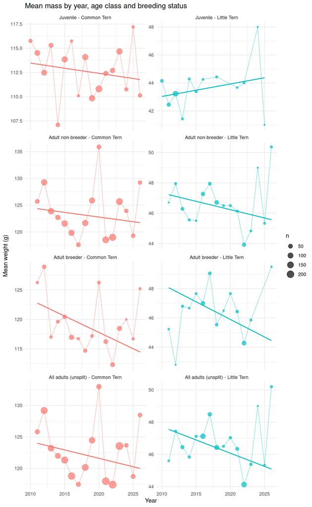

```r
panel_levels <- as.vector(t(outer(levels(combined_by_year$group), c("Common Tern", "Little Tern"), paste, sep = " - ")))

combined_by_year <- combined_by_year %>%
  mutate(panel_label = factor(paste(group, species_label, sep = " - "), levels = panel_levels))

combined_records_panel <- combined_records %>%
  mutate(panel_label = factor(paste(group, species_label, sep = " - "), levels = panel_levels))

ggplot(combined_by_year, aes(year, mean_weight, color = species_label)) +
  geom_line(alpha = 0.4, linewidth = 0.5) +
  geom_point(aes(size = n), alpha = 0.7) +
  geom_smooth(data = combined_records_panel, aes(x = year, y = Weight, color = species_label),
              method = "lm", se = FALSE, linewidth = 0.8) +
  facet_wrap(~panel_label, ncol = 2, scales = "free_y") +
  scale_size_continuous(range = c(1, 6), name = "n") +
  guides(color = "none") +
  labs(title = "Mean mass by year, age class and breeding status",
       y = "Mean weight (g)", x = "Year") +
  theme_minimal()
```

# 5 Trend statistics

Individual-level linear regression of `Weight ~ year`, per species and group (not just correlating the per-year means, so each year is weighted by its actual sample size):

```r
trend_stats <- combined_records %>%
  group_by(species_label, group) %>%
  filter(n() >= 3) %>%   # need at least 3 years' worth of individual points to fit a trend
  group_modify(~ {
    m <- lm(Weight ~ year, data = .x)
    s <- summary(m)
    tibble(
      n = nrow(.x),
      n_years = n_distinct(.x$year),
      slope_g_per_year = round(coef(m)["year"], 3),
      se = round(s$coefficients["year", "Std. Error"], 3),
      p_value = signif(s$coefficients["year", "Pr(>|t|)"], 3),
      r_squared = round(s$r.squared, 3)
    )
  }) %>%
  ungroup()

# p < 0.001 shown in scientific notation (still 3 sig figs); p >= 0.001
# shown as a plain decimal - kable's default column-wide formatting was
# rendering EVERY value in the column in scientific notation (e.g.
# "1.56e-01") just because the smallest value in the column needed it.
format_pval <- function(p) {
  ifelse(p < 0.001, formatC(p, format = "e", digits = 2), formatC(p, format = "f", digits = 3))
}

trend_stats_display <- trend_stats %>%
  mutate(significant = p_value < 0.05, p_value = format_pval(p_value)) %>%
  mutate(across(-significant, ~ ifelse(significant, paste0("<strong>", .x, "</strong>"), as.character(.x)))) %>%
  select(-significant)

kable(trend_stats_display, escape = FALSE,
      caption = "Weight ~ year regression, by species and group (significant rows, p&lt;0.05, in bold)")
```

Weight ~ year regression, by species and group (significant rows, p<0.05, in bold)

| species_label | group | n | n_years | slope_g_per_year | se | p_value | r_squared |
| --- | --- | --- | --- | --- | --- | --- | --- |
| Common Tern | Juvenile | 1231 | 17 | -0.106 | 0.075 | 0.156 | 0.002 |
| **Common Tern** | **Adult non-breeder** | **1593** | **16** | **-0.173** | **0.064** | **0.007** | **0.005** |
| **Common Tern** | **Adult breeder** | **490** | **16** | **-0.554** | **0.114** | **1.58e-06** | **0.046** |
| **Common Tern** | **All adults (unsplit)** | **2083** | **16** | **-0.267** | **0.057** | **3.06e-06** | **0.01** |
| Little Tern | Juvenile | 192 | 12 | 0.089 | 0.08 | 0.266 | 0.006 |
| Little Tern | Adult non-breeder | 224 | 16 | -0.11 | 0.073 | 0.132 | 0.01 |
| **Little Tern** | **Adult breeder** | **184** | **14** | **-0.241** | **0.088** | **0.007** | **0.039** |
| **Little Tern** | **All adults (unsplit)** | **408** | **16** | **-0.164** | **0.056** | **0.004** | **0.021** |

# 6 Does the trend differ between groups?

Interaction test (`Weight ~ year * group`) per species - tests whether the year-slope itself differs significantly across juveniles / non-breeders / breeders, rather than just looking at each group’s trend in isolation:

```r
for (sp in c("Common Tern", "Little Tern")) {
  d <- combined_records %>%
    filter(species_label == sp, group != "All adults (unsplit)") %>%
    droplevels()
  m <- lm(Weight ~ year * group, data = d)
  a <- anova(m)
  p_interaction <- signif(a["year:group", "Pr(>F)"], 3)
  cat("**", sp, "**: year x group interaction p =", p_interaction, "\n\n", sep = "")
}
```

**Common Tern**: year x group interaction p =0.00648

**Little Tern**: year x group interaction p =0.0301

## 6.1 Interpretation

A significant interaction means the mass trend over time is not the same across groups (e.g. breeders declining while juveniles don’t, or vice versa) - that’s the more informative result for the paper than any single group’s trend alone. A non-significant interaction means whatever trend exists (if any) is roughly parallel across groups. Read this alongside the per-group `trend_stats` table above and the plot - small per-year-per-group sample sizes (see `n` columns) mean isolated significant/non-significant results for any one group should be treated cautiously.

# 7 Save outputs

```r
write.csv(combined_by_year %>% select(-species_label), file.path(proc_dir, "mass_trends_by_group.csv"), row.names = FALSE)
write.csv(trend_stats, file.path(proc_dir, "mass_trends_stats.csv"), row.names = FALSE)
cat("Wrote data_processed/mass_trends_by_group.csv and mass_trends_stats.csv\n")
```

```
## Wrote data_processed/mass_trends_by_group.csv and mass_trends_stats.csv
```